# Hacky Hours

11/25/2016

## Why data manipulation?

*“There are no routine statistical questions, only questionable statistical routines.”*

/Sir David Cox/

"*It's commonly said that data scientists spend 80% of their time cleaning and manipulating data and only 20% of their time actually analyzing it. For this reason, it is critical to become familiar with the data cleaning process and all of the tools available to you along the way.*"

## Time and place

**Every Monday 5:30pm (?) at SmR1 or SmR3**

https://github.com/palfalvi/NIBB_Rclub

You will need your computer.

Bring cookies, snacks and drinks to make it more comfortable.

## Using R

**Why R**

- Free
- Easy to learn
- Powerful high-end developers
- Continous supports
- Customizability
- Easy-to-use UI (RStudio)

## The tidyverse

**R for Data Science**

- Data visualization
- Data transformation
- Exploratory data analysis

[figure not shown]

http://r4ds.had.co.nz

## Data visualization

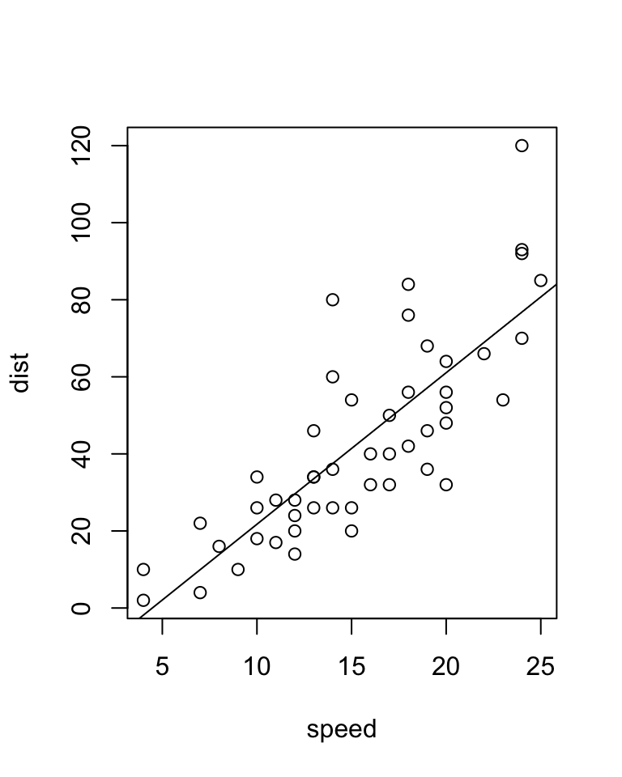

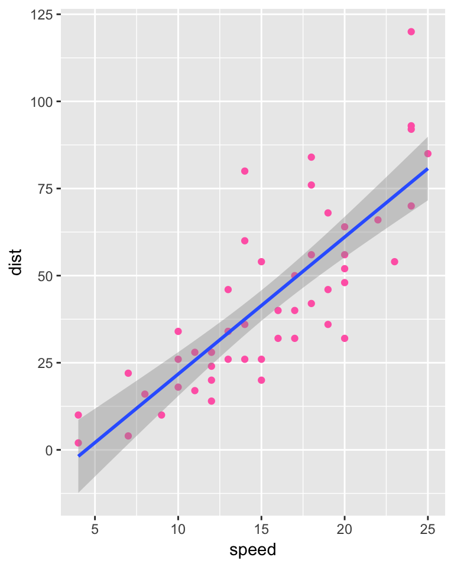

## Data transformation

```r
> wide_format
##         name day1 day2
## 1 John Smith    2    3
## 2 Carl Sagan    6   12
## 3        Bob    4    4
> long_format
##         name  day amount
## 1 John Smith day1      2
## 2 Carl Sagan day1      6
## 3        Bob day1      4
## 4 John Smith day2      3
## 5 Carl Sagan day2     12
## 6        Bob day2      4
```

## Exploratory data analysis

```r
> iris %>% group_by(Species) %>%
+   summarise(mean(Petal.Length),sd(Petal.Length))
## # A tibble: 3 × 3
##      Species `mean(Petal.Length)` `sd(Petal.Length)`
##       <fctr>                <dbl>              <dbl>
## 1     setosa                1.462          0.1736640
## 2 versicolor                4.260          0.4699110
## 3  virginica                5.552          0.5518947
```

## Using others then R

**UNIX, bash**

- "Server language"
- Basic file manipulation
- Job scripting

**Python/Perl/Ruby**

- "Deeper programming"
- Easier string manipulation (sequnece)

**JavaScript, HTML, YAML, php, etc…**

## Complex workbench example

**RNAseq**

- Using existing programs on **UNIX** to
  - QC
  - Mapping
  - Expression counting
- Using random written **Python** scripts to
  - Data management
  - Random feature extractions
- Downstream analysis with **R**
  - Perform statistical analysis on differences
  - Visualize data
  - Make report

## General workflow of data analysis

[figure not shown]

## What is tidy data?

Storing in consistent form

- Each column is a variable (conditions)
- Each row is an observation (genes)

## Installing R and RStudio

- https://cran.r-project.org  
  #Install the most recent R version: 3.3.2 a.k.a. Sincere Pumpkin Patch
- https://www.rstudio.com #Install the most recent Rstudio: v1.0.44 (Important, new features!)

## Installing packages

```r
> install.packages("tidyverse")
> library(tidyverse)
>
> #From Bioconductor (bioconductor.org)
> source("https://bioconductor.org/biocLite.R")
> biocLite("TCC")
> library(TCC)
```

## Coding basics

```r
> 1 / 100 * 26
## [1] 0.26
> (59 + 73 + 2) / 3
## [1] 44.66667
> sin(pi / 2)
## [1] 1
```

## Objects

What is a variable/object?

```r
> object_name <- value
```

```r
> x <- 5
> x
## [1] 5
>
> y <- 3 * 4
> y
## [1] 12
```

## Tips on naming

- Use consistent style in your code
- Add informative names
  - `x` –> too short, easy to forget the content
  - `these_are_the_expression_values` –> too long
  - `expr_ltpm` –> informative, good length

```r
> i_use_snake_case
> otherPeopleUseCamelCase
> some.people.use.periods
> And_aFew.People_RENOUNCEconvention
```

## Tips on typing

- CTRL+Up / CMD+Up to show history
- Tab to finish variable/function names
- Alt+Shift+K / Opt+Shift+K

## Functions

`function_name(argument1 = value1,argument2 = value2, ...)`

```r
> seq(from = 0, to = 10, by = 2)
## [1]  0  2  4  6  8 10
> seq(from = 0, to = 10, length.out = 6)
## [1]  0  2  4  6  8 10
> seq(0,10,2)
## [1]  0  2  4  6  8 10
```

## Data import/export

- **Plain-text rectangular files**
- Pictures
- Binary files
- Connections

Base R:

```r
> read.table() # space, tab and any charachter
> read.csv() # , separated
> read.csv2() # ; separated
```

## Data import/export with tidyverse

- `readr` package
- ~10x faster
- automatically converts to `tibble` objects
  - No `stringsAsFactors`

```r
> read_table() # space (or tab)
> read_csv() # ,
> read_csv2() # ;
> read_tsv() # tab
> read_delim() # any charachter
```

## Practice

https://github.com/palfalvi/NIBB_Rclub

Download

- anorexia_bad.xlsx
- anorexia.csv
- pokemons.csv

Try some functions: * `summary()` * `t.test()`

## Parsing rules

```r
> guess_parser("2010-10-01")
## [1] "date"
> guess_parser(c("TRUE", "FALSE"))
## [1] "logical"
> guess_parser(c("1", "5", "9"))
## [1] "integer"
> guess_parser(c("12,352,561"))
## [1] "number"
```

## Parsing numbers - decimals

- R is US centric

```r
> # Used in USA (and Japan)
> parse_double("1.23")
## [1] 1.23
>
> # Used in many parts of Europe
> parse_double("1,23", locale = locale(decimal_mark = ","))
## [1] 1.23
```

## Parsing numbers - grouping

```r
> # Used in USA (and Japan)
> parse_number("$123,456,789")
## [1] 123456789
>
> # Used in many parts of Europe
> parse_number("123.456.789", locale = locale(grouping_mark = "."))
## [1] 123456789
>
> # Used in Switzerland
> parse_number("123'456'789", locale = locale(grouping_mark = "'"))
## [1] 123456789
```

## Parsing texts (strings)

```r
> x1 <- c("\x82\xb1\x82\xf1\x82ɂ\xbf\x82\xcd")
> x1
## [1] "\x82\xb1\x82\xf1\x82\u0242\xbf\x82\xcd"
> parse_character(x1, locale = locale(encoding = "Shift-JIS"))
## [1] "こんにちは"
```

If not working, set locale:

```r
> Sys.setlocale("LC_CTYPE", "en_US.UTF-8")
## [1] "en_US.UTF-8"
```

## Parsing texts (strings)

```r
> x2 <- charToRaw("こんにちは")
> x2
##  [1] e3 81 93 e3 82 93 e3 81 ab e3 81 a1 e3 81 af
> rawToChar(x2)
## [1] "こんにちは"
```

## Other origins of data

- `xlsx` package (not in tidyverse)
  - for Excel data
- `foreign` package (not in tidyverse)
  - SAS
  - SPSS
  - Stata

## Base R objects - Vectors

```r
> a <- c(1,2,3,4,5.3,-3) # numeric vector
> a
## [1]  1.0  2.0  3.0  4.0  5.3 -3.0
> b <- c("one","three","cheese") # character vector
> b
## [1] "one"    "three"  "cheese"
> c <- c(TRUE,TRUE,FALSE,TRUE) # logical vector
> c
## [1]  TRUE  TRUE FALSE  TRUE
```

## Base R objects - Matrices

```r
> y<-matrix(1:20, nrow=4,ncol=5) #default arrangment is by column
> y
##      [,1] [,2] [,3] [,4] [,5]
## [1,]    1    5    9   13   17
## [2,]    2    6   10   14   18
## [3,]    3    7   11   15   19
## [4,]    4    8   12   16   20
>
> cells <- c(1,26,24,68)
> rnames <- c("R1", "R2") # row names
> cnames <- c("C1", "C2") # column names
> mymatrix <- matrix(cells, nrow=2, ncol=2, byrow=TRUE,dimnames=list(rnames, cnames))
> mymatrix
##    C1 C2
## R1  1 26
## R2 24 68
```

## Base R objects - Data frames

```r
> d <- c(1,2,3,4)
> e <- c("red", "white", "red", NA)
> f <- c(TRUE,TRUE,TRUE,FALSE)
> mydata <- data.frame(d,e,f)
> names(mydata) <- c("ID","Color","Passed") # variable names
> mydata
##   ID Color Passed
## 1  1   red   TRUE
## 2  2 white   TRUE
## 3  3   red   TRUE
## 4  4  <NA>  FALSE
```

Remember about tidy data:

- Each column is a variable (conditions)
- Each row is an observation (genes)

## Base R objects - Lists

```r
> w <- list(name="Fred", mydata=mydata, age=5.3)
> w
## $name
## [1] "Fred"
##
## $mydata
##   ID Color Passed
## 1  1   red   TRUE
## 2  2 white   TRUE
## 3  3   red   TRUE
## 4  4  <NA>  FALSE
##
## $age
## [1] 5.3
```

## Subsetting practice

use `airquality`, `mtcars`, `DNase`, `PlantGrowth`, `anscombe`, `iris` datasets

## Introducing `tibble`

- Tibbles *are* data frames
- Never changes an input’s type (no more `stringsAsFactors = FALSE` !)
- Use with list-columns
- Never adjusts the names of variables
- Never uses `row.names()` (remember about tidy data)
- More strict on subsetting (with [, [[ and $)
- Always adapt to screen size

## Converting to tibble

```r
> as_tibble(iris)
## # A tibble: 150 × 5
##    Sepal.Length Sepal.Width Petal.Length Petal.Width Species
##           <dbl>       <dbl>        <dbl>       <dbl>  <fctr>
## 1           5.1         3.5          1.4         0.2  setosa
## 2           4.9         3.0          1.4         0.2  setosa
## 3           4.7         3.2          1.3         0.2  setosa
## 4           4.6         3.1          1.5         0.2  setosa
## 5           5.0         3.6          1.4         0.2  setosa
## 6           5.4         3.9          1.7         0.4  setosa
## 7           4.6         3.4          1.4         0.3  setosa
## 8           5.0         3.4          1.5         0.2  setosa
## 9           4.4         2.9          1.4         0.2  setosa
## 10          4.9         3.1          1.5         0.1  setosa
## # ... with 140 more rows
```

## Open files as tibbles

Use `read_*()` instead of `read.*()`  
(Sometimes use `read.table()` and `as_tibble()`)

| Arguments |  |
| --- | --- |
| `file` | Either a path to a file, a connection, or literal data |
| `col_names` | Either TRUE, FALSE or a character vector of column names. |
| `col_types` | One of NULL, a cols specification, or a string. |
| `na` | Character vector of strings to use for missing values. |
| `skip` | Number of lines to skip before reading data. |

For more information: `?read_table`

## More practice

https://github.com/palfalvi/NIBB_Rclub

Download and open as tibbles

- anorexia_bad.xlsx
- anorexia.csv
- pokemons.csv

Try some functions: * `summary()` * `t.test()`

Practice subsettings

## Visualizing data - Basic plots

- R has built-in plotting functions
  - `plot()`
  - `boxplot()`
  - `hist()`
  - etc…

## Visualizing data - Basic examples

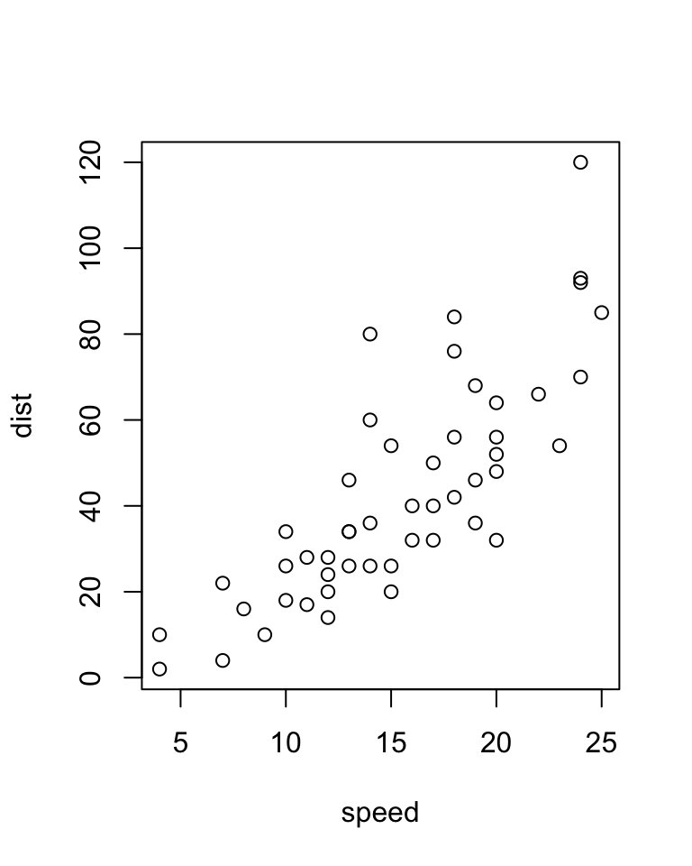

```r
> plot(cars)
```

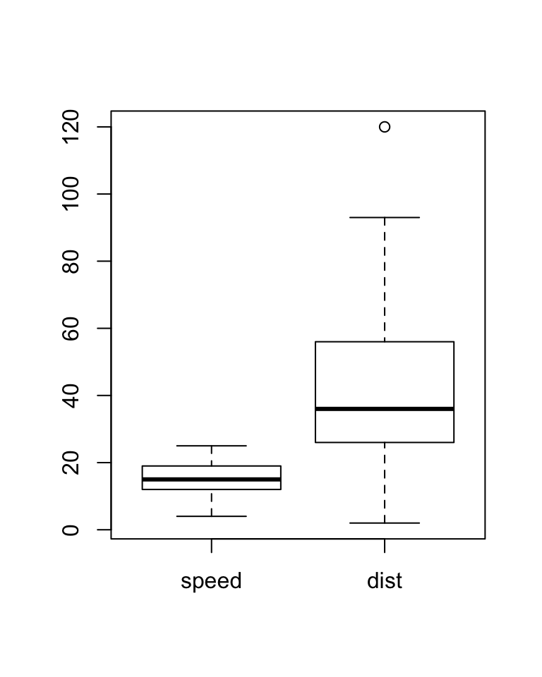

```r
> boxplot(cars)
```

## Visualizing data - in a tidy way

- Using *Grammar of Graphics*
  - Data
  - aes(thetics)
  - geom(metrics)

[figure not shown]

- `ggplot2` package

## Visualizing data - ggplot example

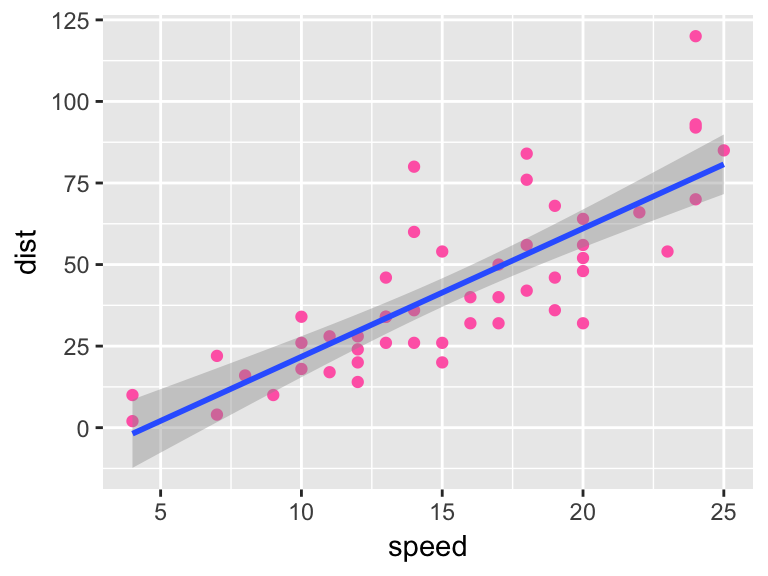

```r
> ggplot( data = cars, aes(x = speed, y = dist )) +
+   geom_point( color = "hotpink" ) +
+   geom_smooth( method = "lm" )
```

## Question - What is the difference?

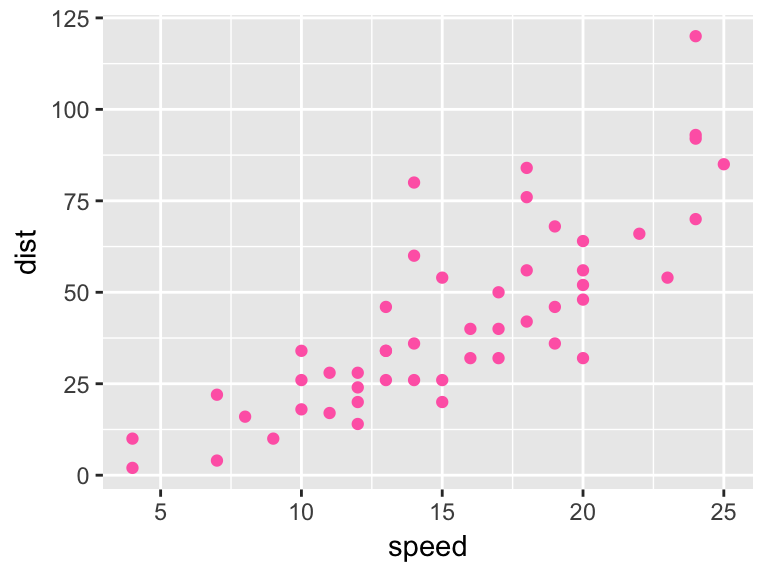

```r
> ggplot( data = cars,
+         aes(x = speed, y = dist )) +
+   geom_point( color = "hotpink" )
```

```r
> ggplot( data = cars ) +
+   geom_point(aes(x = speed, y = dist),
+              color = "hotpink" )
```

Let's try to add `geom_smooth(method="lm")`

## Aesthetic mappings

- Color - discrete or continuous
- Shape - discrete
- Size - continuous
- Alpha (transparency) - continuous

## Aesthetic mapping - example

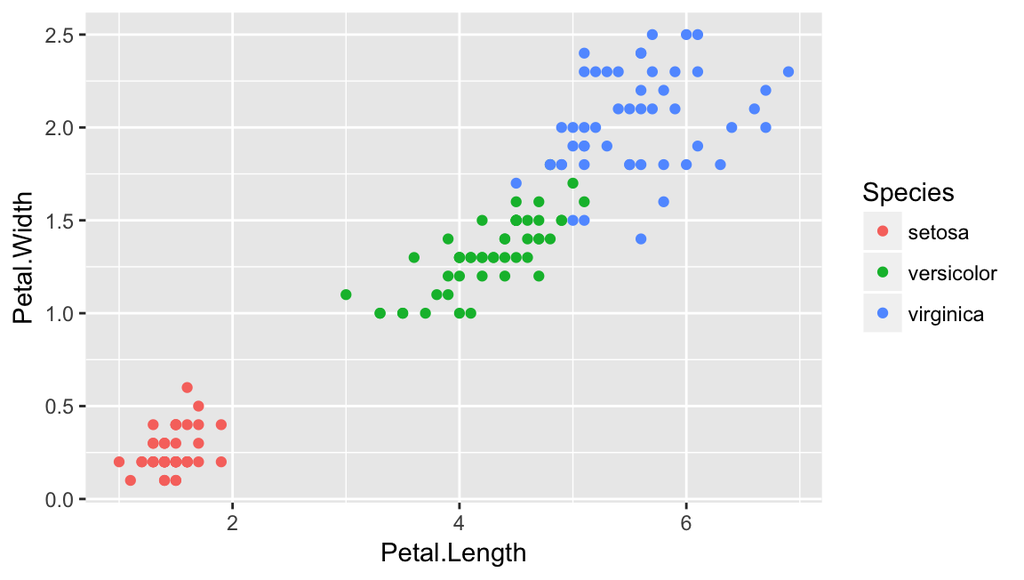

```r
> ggplot(data = iris) +
+   geom_point(aes(x = Petal.Length,
+                  y = Petal.Width,
+                  color = Species))
```

## Facetting - with one variable

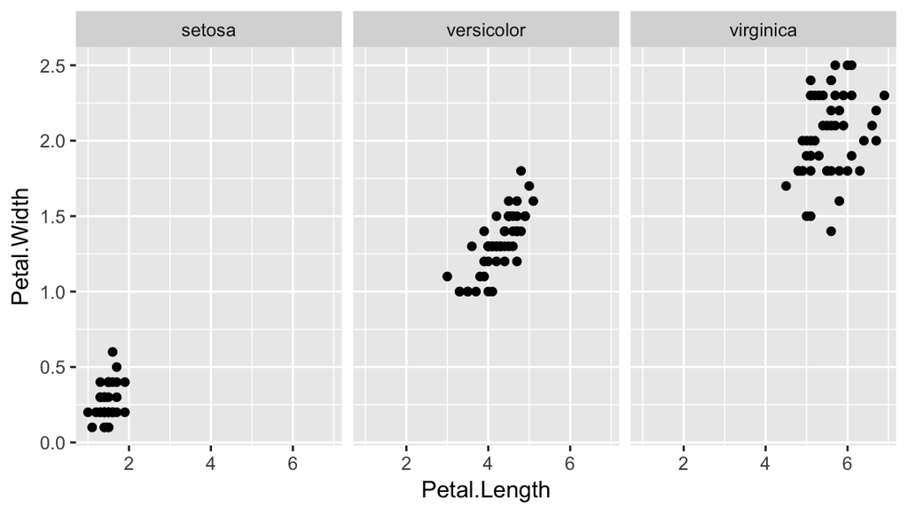

```r
> ggplot(data = iris) +
+   geom_point(aes(x = Petal.Length,
+                  y = Petal.Width)) +
+   facet_wrap(~ Species)
```

## Facetting - with 2 variables

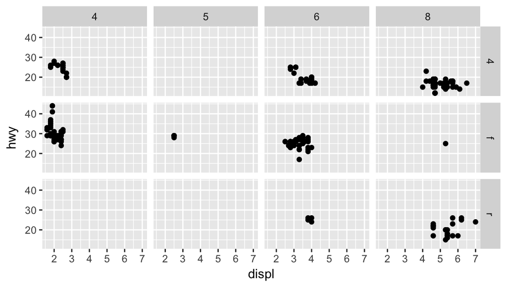

```r
> ggplot(data = mpg) +
+   geom_point(mapping = aes(x = displ, y = hwy)) +
+   facet_grid(drv ~ cyl)
```

## Geometric objects

|  | Primitives | One variable | Two variables cont x,y | Two variables disc x, cont y | Errors |
| --- | --- | --- | --- | --- | --- |
| `geom_` | `blank()` `curve()` `path()` `polygon()` `rect()` `ribbon()` `segment()` | `area()` `density()` `dotplot()` `freqplot()` `histogram()` | `label()` `jitter()` `point()` `quantile()` `rug()` `smooth()` `text()` | `bar()` `boxplot()` `dotplot()` `violin()` | `crossbar()` `errorbar()` `linerange()` `pointrange()` |

## Using global aesthetics

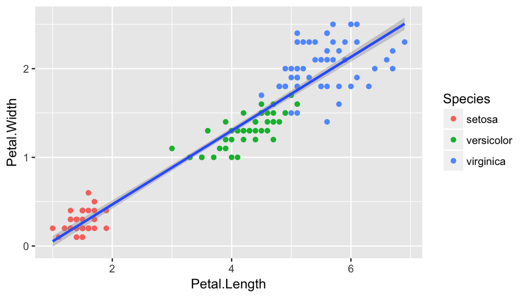

```r
> ggplot(data = iris,
+        aes(x = Petal.Length,
+            y = Petal.Width)) +
+   geom_point(aes(color = Species)) +
+   geom_smooth(method="lm")
```